# STATS 3001 / STATS 4104 / STATS 7054 Statistical Modelling III Workshop 3 - GAMs

John Maclean

Week 2

Load packages

```r
pacman::p_load(tidyverse, gglm, broom)
```

## Preface

What makes a linear model linear? Suppose you model data $Y$. This is the standard linear model:

$$Y = X\beta + \epsilon.$$

(Assume that $\epsilon$ has mean 0 and variance $\sigma^2I$, &etc.)

1. Which of the following are linear models?

$$\log(Y) = X\beta + \epsilon.$$
$$Y = \log(X)\beta + \epsilon.$$
$$Y = X {\log(\beta)} + \epsilon.$$
$$Y^2 = e^X\beta + \epsilon.$$

## Can you always transform data to get to linearity?

Consider the following plot, showing a predictor vs a response variable,

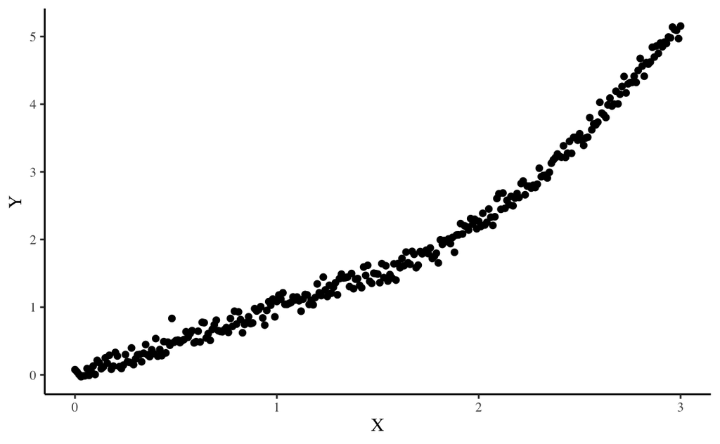

```r
 p <- df %>% ggplot(aes(X,Y)) + geom_point()
p
```

Let me expose the data so you can play with it:

```r
X <- seq(0,3,by=0.01) #predictor
bnd <-mean(X) #boundary between linear and nonlinear response
a <- 1 #arbitrary
b <- -2*bnd*a #match first derivatives at X=7
c <- -bnd^2*a-bnd*b #match value at X=7
Y <- X + (X>bnd) * ( a*X^2 + b*X + c) #combines linear and nonlinear response
s = 0.07
Y <- Y + rnorm(length(X),sd=s)#add noise

#make dataframe
df <- tibble(X=X, Y=Y)
```

2. Work out what relationships are included in this data, and consider whether any data transformation you can think of is viable to obtain a linear response.

### Key question

3. What if you employ different transformations on either side of this vertical line?

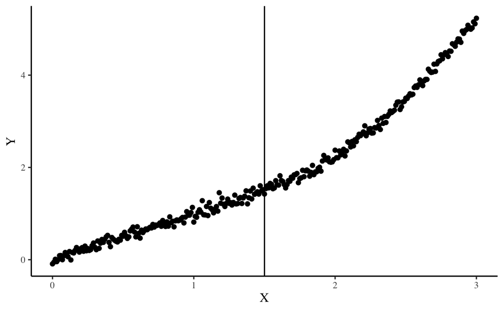

```r
df %>% ggplot(aes(X,Y)) + geom_point() + geom_vline(xintercept = bnd)
```

Call $x=1.5$ a ‘knot’ and suppose we can employ different transformations on either side of the knot. Could you employ a linear model then? (Do not try to implement such a model.)

Pause here to note two questions (that you cannot answer - yet).

- how do we identify knots to separate different data transforms? I specified above - need to automate.
- how do we identify good transformations of the data?

## Notation

An idea is to fit the model

$$Y_i = \alpha + f(X_i) + \epsilon_i \;,$$

where
$$f(X_i) = \sum_{j=1}^p \beta_j
b_j(X_i)$$

is linear in the coefficients $\beta_j$ and builds an approximation of $Y_i$ using *basis functions* $b_j$. We will refer to these functions as *smoothers*.

Here’s an example of cubic smoothers:

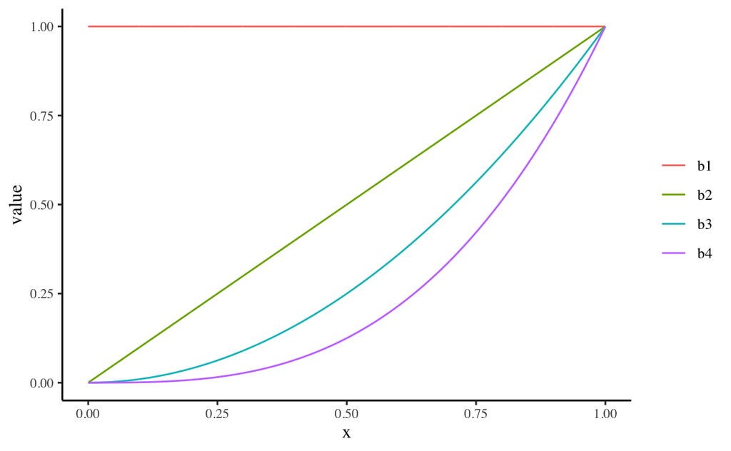

```r
x <- seq(0,1,by=0.001)
b1 <- 1
b2 <- x
b3 <- x^2
b4 <- x^3

df_splines <- tibble(x,b1,b2,b3,b4)
df_splines %>% pivot_longer(cols=b1:b4) %>%
  ggplot(aes(x,value,color=name)) + geom_line()
```

# Try out GAM

Recall. The idea is to separate your predictor space into regions bounded by *knots*, and then to seek a flexible data transformation (employing basis functions) called a *smoother*, that lets you flexibly model data. The result is a linear model because (refer the worksohp start) it is linear in the coefficients $\beta_j$.

The implementation of this idea is called a Generalised Additive Model or GAM. GAMs are flexible, allowing you to select many specific features of the above. GAMs also come with an automatic parameter selection process that attempts to find the ‘best’ smoother available. In the remainder of the workshop, I want you to:

4. Begin. Load the mgcv package,

```r
pacman::p_load(mgcv)
```

and try the code

```r
gam_model <- mgcv::gam(Y ~ s(X), data = df)
summary(gam_model)
```

```
##
## Family: gaussian
## Link function: identity
##
## Formula:
## Y ~ s(X)
##
## Parametric coefficients:
##             Estimate Std. Error t value Pr(>|t|)
## (Intercept) 1.876362   0.004288   437.6   <2e-16 ***
## ---
## Signif. codes:  0 '***' 0.001 '**' 0.01 '*' 0.05 '.' 0.1 ' ' 1
##
## Approximate significance of smooth terms:
##        edf Ref.df     F p-value
## s(X) 6.594  7.726 13904  <2e-16 ***
## ---
## Signif. codes:  0 '***' 0.001 '**' 0.01 '*' 0.05 '.' 0.1 ' ' 1
##
## R-sq.(adj) =  0.997   Deviance explained = 99.7%
## GCV = 0.0056771  Scale est. = 0.0055339  n = 301
```

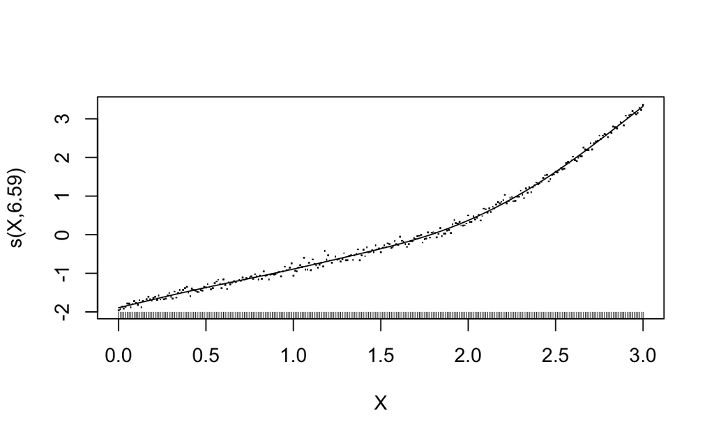

```r
plot(gam_model,residuals = TRUE, se = FALSE)
```

Note the `s(X)` tells GAM which predictors to smooth. Note 2 there are multiple `gam` functions that exist from various packages. I use `mgcv::gam` to specify which package/function uniquely.

5. Get the estimated coefficients from the model. (Try the `coef` function)
6. Tweak smoothness

The smoother `s()` tries to fit data by interpolating between data points. The goal is to follow the broad trend of the data without getting ‘too wiggly’. Try specifying the `sp` argument like `s(X, sp=...)`to affect how closely the smoother will match the data. Try sp = 10000 - should see something similar to linear regression - and sp = 0.1.

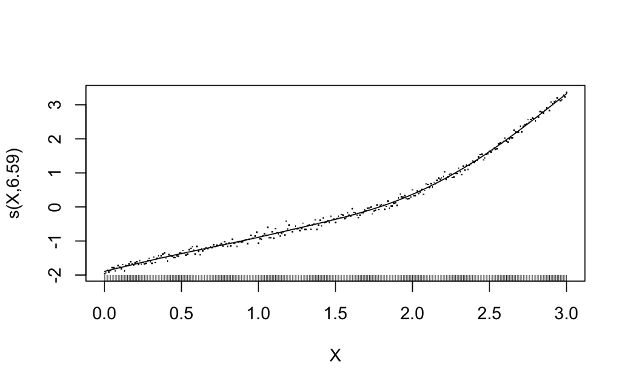

```r
gam_model <- mgcv::gam(Y ~ s(X), data = df)
plot(gam_model,residuals = TRUE, se = FALSE)
```

7. Load the isit data and try fitting a gam to station 6. Have a look at the default interpolation and try different values of `sp`.

```r
isit <- read_delim("workshops/ZuurData/Isit.txt") #read_delim will infer the delimitor
```

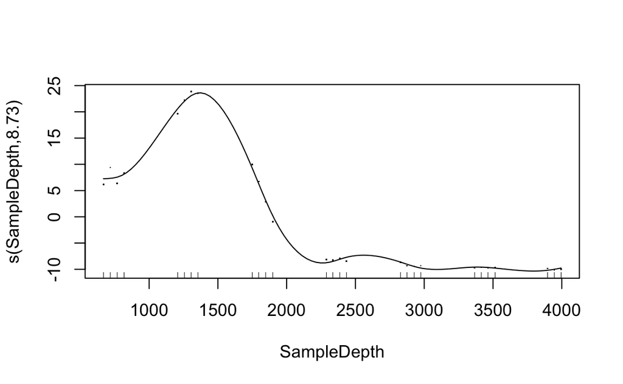

```r
isit6 <- isit %>% filter(Station==6)
gam6 <- mgcv::gam(Sources~s(SampleDepth), data = isit6)
plot(gam6,residuals = TRUE, se = FALSE)
```

8. View smoother predictions

Compare the output of these predict commands:

```r
gam6_out <- predict(gam6, newdata=isit6)
gam6_out
```

```
##           1           2           3           4           5           6
## 33.15151211 33.67289156 32.11574173 30.68086641 19.32531735 17.39397277
##           7           8           9          10          11          12
## 18.18346851 16.41151700 17.62687253 17.32125373 13.22457549 10.25455661
##          13          14          15          16          17          18
##  1.98332511  1.31884354  1.56818042  2.36248741  1.43850484  1.03046040
##          19          20          21          22          23          24
##  0.30552076  0.60633657  0.48349040  0.29804820  0.48834317  0.41862225
##          25          26          27
## -0.11675222  0.30912120  0.07292216
```

```r
gam6_parts <- predict(gam6, newdata=isit6, type = "lpmatrix") #like model matrix
gam6_parts
```

```
##    (Intercept) s(SampleDepth).1 s(SampleDepth).2 s(SampleDepth).3
## 1            1       1.05715887       0.27095790      0.983038309
## 2            1       1.03283312       0.23763929      0.891526285
## 3            1       1.07737823       0.29929006      1.060758171
## 4            1       1.09481002       0.32501233      1.128713383
## 5            1       0.73066075      -0.13809453      0.087305020
## 6            1       1.14295065       0.49073189      1.338865938
## 7            1       1.14463551       0.46234642      1.339350986
## 8            1       0.68336421      -0.18932381      0.021171989
## 9            1       1.14405751       0.47647923      1.340134071
## 10           1       1.14161977       0.50507275      1.336727911
## 11           1       0.62797351      -0.24585095     -0.037687537
## 12           1       0.56818443      -0.30168621     -0.081673229
## 13           1      -0.10998767      -0.56994293     -0.003867529
## 14           1       0.03555589      -0.56684023     -0.051599044
```

[output cut: 71 more lines]

Try to reconstruct `gam6_out` from `gam6_parts`. Hint: you need something from earlier in the workshop.

9. Change number of basis functions

Replace the `sp` optional argument to `s()` with `k`. Try k=3, k=10, k=20. Use your prior code to work out what is changing.